# STAT154Project2

ShiyangNi

4/28/2019

```r
library(dplyr)
```

```r
library(ggplot2)
library(gridExtra)
library(klaR)
library(plotly)
library(scatterplot3d)
```

### 1. Data Collection and Exploration (30 pts)

1. Study Summary
2. Data Basics

Each image is of size $382 \times 305$ pixels, and each pixel represents a $275 \times 275m$ window of earth surface. For each pixel, our dataset documents its x,y coordinates, an expert label indicating whether the pixel is clouded, five angular raidance readings from MISR satelitte, and three custom-created features capturing inter-pixel or inter-angular-channel dependencies.

A quick recreation of the three images is shown below, with black representing pixels not clouded, white clouded and grey not confident enough to judge. As we can see, all three pictures have a rather significant portion of pixels that experts cannot confidently label: image1 has 38% grey, image2 28% and image3 52%. These undetermined pixels contain no useful information about cloud existence, and therefore cannot be used in either training or testing.

Should we just throw them away? One might be concerned that a simple discard would break spatial/geological dependency, leading to worse paramter estimation. Our counter argument is that for basic Generalized Linear MOdels(logistics, LDA/QDA) that don’t explicitly take into account the local interactions between variables(such as by including an interaction term $x_1 * x_2$), **sporadically** deleting some samples wouldn’t degrade the model quality by much. Basic linear paradigms all assume some smooth global relationships between the class posteriors and the features; such global smoothness constraint implies the functions are unlikely to have irregular local behavior. So as long as our remaining samples can loosely cover the feature space, we can afford to delete some samples. *Justificaiton for SVM? Tree-based?*

Of course, a better fix would be to go back to data collection stage, and augment these unlabeled pixels with more meaningful information, such as the confidence level with which the pixel is clouded. Under proper justification from prior knowledge, we might be able to use that confidence level as a surrogate for the class posterior, and produce a more informative model.

3. Visual and Quantitative EDA

```r
##Loading the data
header = c("x", "y", "expert_label", "NDAI", "SD", "CORR", "raDF", "raCF", "raBF", "raAF", "raAN")
image1 = read.table("../data/image1.txt", col.names = header)
image2 = read.table("../data/image2.txt", col.names = header)
image3 = read.table("../data/image3.txt", col.names = header)
##Image Dimensions
image1$x %>% table() %>% names() %>% length()
```

```
## [1] 382
```

```r
image1$y %>% table() %>% names() %>% length()
```

```
## [1] 305
```

```r
image2$x %>% table() %>% names() %>% length()
```

```
## [1] 382
```

```r
image2$y %>% table() %>% names() %>% length()
```

```
## [1] 304
```

```r
image3$x %>% table() %>% names() %>% length()
```

```
## [1] 382
```

```r
image1$y %>% table() %>% names() %>% length()
```

```
## [1] 305
```

```r
##Clouded pixels
#Coverage
mean(image1[,3] == 0)
```

```
## [1] 0.384556
```

```r
mean(image2[,3] == 0)
```

```
## [1] 0.2863522
```

```r
mean(image3[,3] == 0)
```

```
## [1] 0.5226746
```

```r
#Clouded vs unclouded
image1_confident = image1[image1[,3] != 0,]
image2_confident = image2[image2[,3] != 0,]
image3_confident = image3[image3[,3] != 0,]
mean(image1_confident[,3] == 1)
```

```
## [1] 0.2886614
```

```r
mean(image2_confident[,3] == 1)
```

```
## [1] 0.4779909
```

```r
mean(image3_confident[,3] == 1)
```

```
## [1] 0.3862826
```

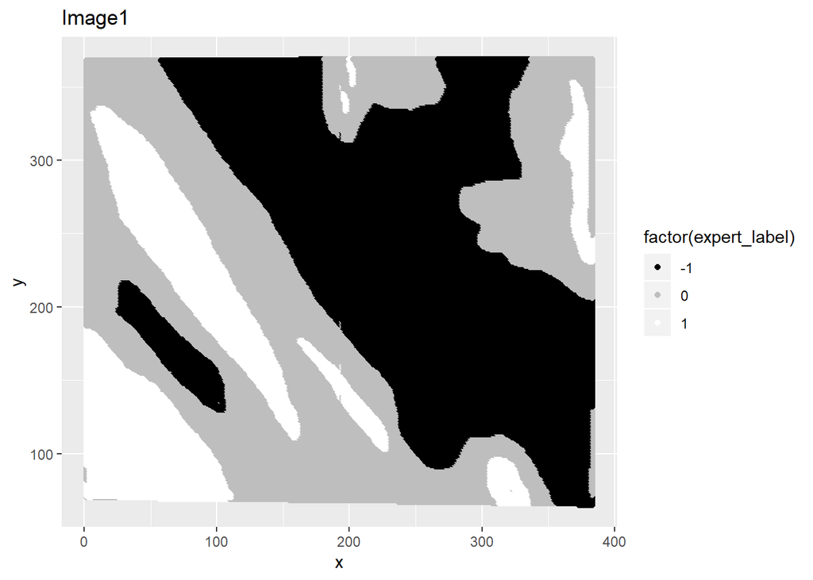

```r
##Reproducing the pictures
ggplot(image1) + geom_point(aes(x = x, y = y, color = factor(expert_label))) + scale_color_manual(values = c("black","grey","white")) +
  labs(title = "Image1", xlab = "", ylab = "")
```

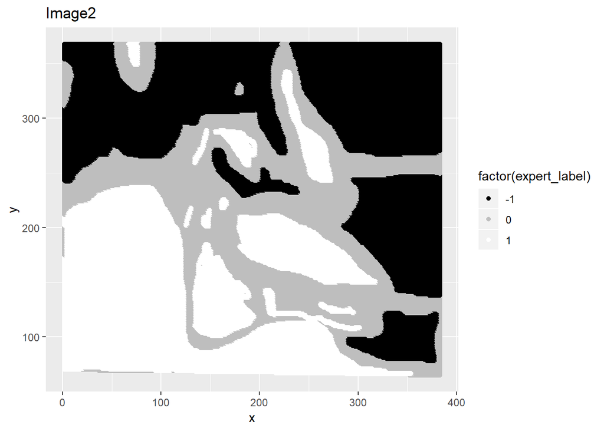

```r
ggplot(image2) + geom_point(aes(x = x, y = y, color = factor(expert_label))) + scale_color_manual(values = c("black","grey","white")) +
  labs(title = "Image2")
```

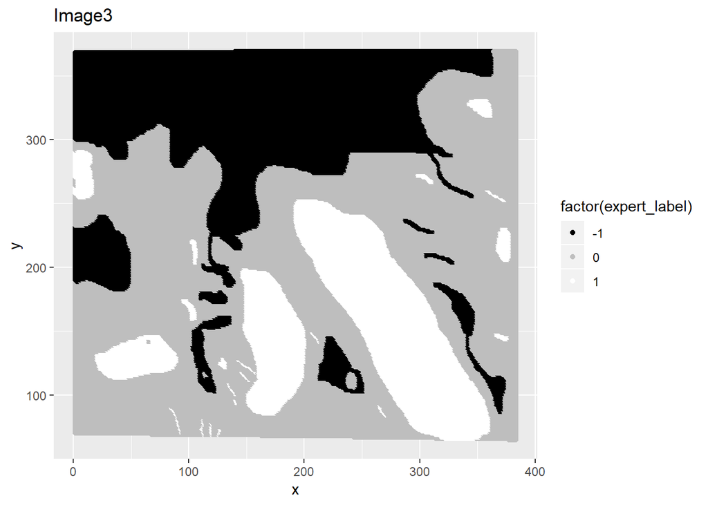

```r
ggplot(image3) + geom_point(aes(x = x, y = y, color = factor(expert_label))) + scale_color_manual(values = c("black","grey","white")) +
  labs(title = "Image3")
```

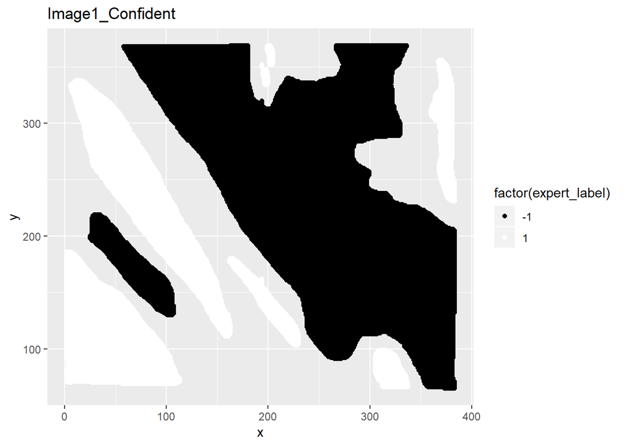

```r
##Reproducing the confident pictures
ggplot(image1_confident) + geom_point(aes(x = x, y = y, color = factor(expert_label))) + scale_color_manual(values = c("black","white")) +
  labs(title = "Image1_Confident")
```

[figure not shown]

```r
ggplot(image2_confident) + geom_point(aes(x = x, y = y, color = factor(expert_label))) + scale_color_manual(values = c("black","white")) +
  labs(title = "Image1_Confident")
```

[figure not shown]

```r
ggplot(image3_confident) + geom_point(aes(x = x, y = y, color = factor(expert_label))) + scale_color_manual(values = c("black","white")) +
  labs(title = "Image1_Confident")
```

### 2. Preparation

1. Data Splitting
- Test Set?

Both ways of splitting uses the entire image3 as the test set. This is to best simulate real-life prediction sceanarios, where the actual test picture always comes in individually. If we had created the test set using partial information from all three images, then we would have introduced some form of spatial correlation between training and test dataset that doesn’t exist in a real prediction setting. For models that are able to pick up such correlation, our test set would yield a potentially higher accuracy rate than a real-life test set would.

Why the third image? Because it’s the newest. Preservation of temporal order also mimics the real prediction setting, where only old information (image1 and image2) is used to train and validate our model.

The tradeoff is of course we are losing around 30% samples to training. Nevertheless, given that the sample size is already large, we decided to stress the structural integrity of the test set.

- Training vs Validation Set: Method One

Method: Divide each image into four quadrants, so we have 8 quadrants in total. Pick one as validation, and leave the other seven as training.

Rationale: Training set preserves space-based structure; Validation set covers unbalanced cases.

In analogy to time series data, randomly splitted training data would only partially preserve space-based structures, if such structures do exist. For models that pick up space-based dependency, this would hurt the quality of parameter estimation. If space-based dependency is further explicitly modeled (such as in time series, an AR(1) model), a training set with randomly punched small holes wouldn’t satisfy the spacing requirement. By dividing each image quadrant-wise, we’re attempting to best preserve any space-based structure.

Our validation set is one quadrant from one image (we use image2’s first quadrant here). It’s similar to an actual test image in the sense that width and height are shrunk by the same proportion. One possible downfall: due to the sheer size of the clouds, the quadrant might be more heavily covered or exposed by cloud than an actual image. But that doesn’t disqualify the quadrant from being a proper validation set: an unbalanced/distorted validation set can identify the model that performs well on unbalanced data. In practice we should expect some test data to be highly imbalanced, as clouds can be very large. Armed with algorithms identifies unbalanced input (judging whether an image is mostly white shouldn’t be that hard of a problem to computer vision experts), we can use the winning classifier on unbalanced test data.

- Training vs Validation Set: Method Two

Method:

Rationale: Generalizing to potentially defected images.

Every coin has two sides. If our future data comes in the exact form (same size, same feature space, similar quality, etc.) as our current data, then we should expect that they are equally capable in preserving any space-based structures. But what if for some reason, such as cameras/sensors aging, our future unlabeled images come with “holes” – pixels where readings aren’t properly recorded? (This isn’t an uncommon problem in remote sensing, as indicated by our first project.) Any space-based dependency would be corrupted in the first place, and we would need to extrapolate the missing information.

In this case, models that don’t take into account space-based dependcy might be a better option. Any models that don’t address space-based structures should remain robust under randomly splitted data. So we devise a randomized splitting scheme to identify such models.

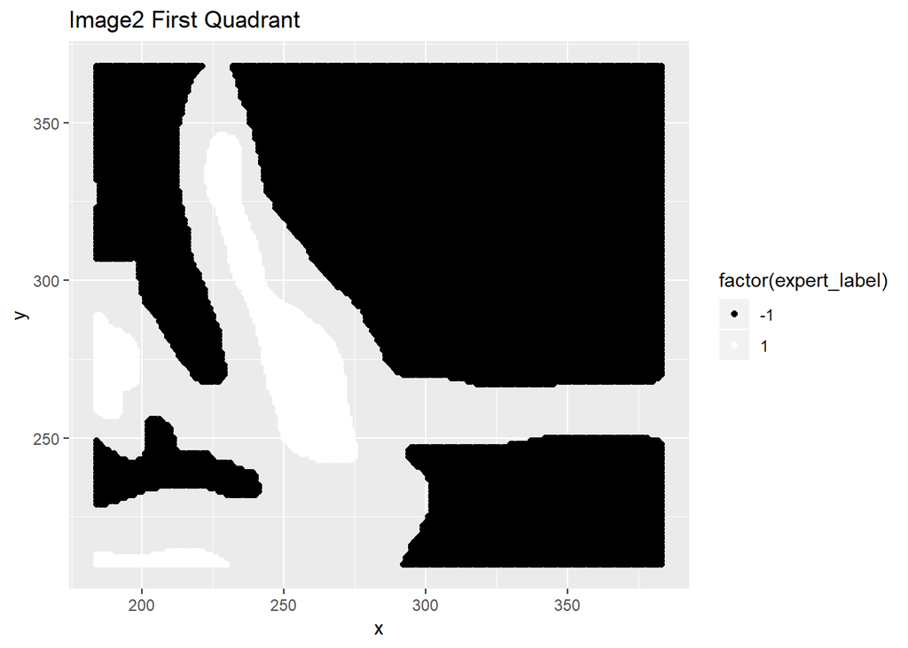

```r
##Quadrant Non-random split. Validation is first quadrant of second image.
val_nonrandom = image2_confident[(image2_confident$x > median(image2_confident$x)) & (image2_confident$y) > median(image2_confident$y), ]

ggplot(val_nonrandom) + geom_point(aes(x = x, y = y, color = factor(expert_label))) + scale_color_manual(values = c("black","white")) +
  labs(title = "Image2 First Quadrant")
```

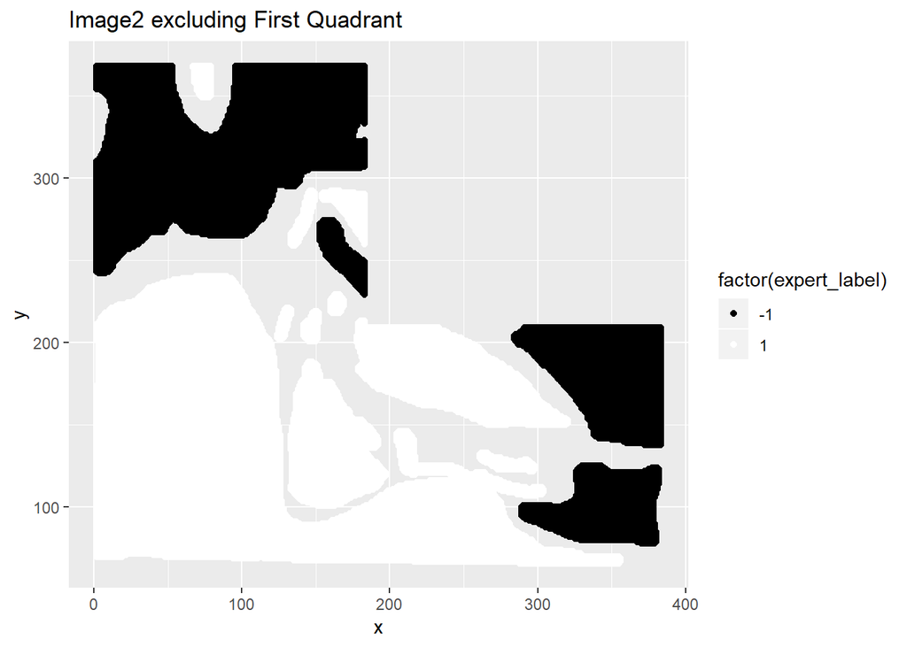

```r
image2_confident_234quadrant = image2_confident[!((image2_confident$x > median(image2_confident$x)) & (image2_confident$y) > median(image2_confident$y)),]

ggplot(image2_confident_234quadrant) + geom_point(aes(x = x, y = y, color = factor(expert_label))) + scale_color_manual(values = c("black","white")) +
  labs(title = "Image2 excluding First Quadrant")
```

```r
train_nonrandom = rbind(image1_confident, image2_confident_234quadrant)
```

```r
training_temp = rbind(image1_confident %>% mutate(picture_number = "one"), image2_confident %>% mutate(picture_number = "two"))
test = image3_confident
```

[figure not shown]

```r
size_nontest = nrow(training_temp)
set.seed(123456)
val_index_random = sample(1:size_nontest, size_nontest/8)
val_random = training_temp[val_index_random, ]
train_random = training_temp[-val_index_random, ]
##Getting a sense of what our validation data looks like
ggplot(val_random) + geom_point(aes(x = x, y = y, color = factor(expert_label))) + scale_color_manual(values = c("black","white")) +
  labs(title = "Randomly picked 1/4 of Image2")
```

2. Null classifier performance

```r
mean(val_nonrandom$expert_label == 1)
```

```
## [1] 0.1032907
```

```r
mean(val_random$expert_label == 1)
```

```
## [1] 0.3892751
```

```r
mean(test$expert_label == 1)
```

```
## [1] 0.3862826
```

3. First order importance – Pick Three Features

If a feature performs very differently between clouded and not clouded pixels, then it likely has some predictive power. We look at summary statistics for a quick search of suspects. For each potentially influential feature, we histogram its respective distributions among clouded and unclouded pixels, and see if the two distributions are separate enough to give any predictive power.

The mean and median of `NDAI`, `SD` and `CORR` are all significantly higher among clouded pixels than non-clouded pixels. Histograms conditioned on cloud existence also look promisingly separate – for each of the three features, there exists some non-trivial feature range for which the class posterior $\mathbb{P}(Y = 1|X_j = x)$ (where $X_j$ denotes the jth component the complete feature vector) is dominatingly high. Note that although the separateness of conditional distributions provide some intuitive justification for some thresholding scheme, it doesn’t provide the threshold values. We need an in-depth analysis of the class posterior conditioned jointly on the three features to establish proper thresholds.

We find the above patterns using the first two pictures as the training set. In practice the test set always comes as one individual picture, so it’s important to make sure what we find here doesn’t break down when we are only using one picture. We repeat the histograms in image1 and image2 separately, and see if the pattern still holds.

Though for both image1 and image2 the conditional distribution of three features are still separate, the pattern is more distinctive in image2 than in image1. This begs the question of to what degree the importance of `NDAI`, `CORR`, and `SD` can be generalized to new pictorial inputs. If we had more pictures, we would algorithimcally test the degree of separateness by developing proper metrics. For this project, we will just settle for what we have.

```r
##A quick glance at the summary statistics
training_temp %>% group_by(expert_label) %>% summarise_all(mean)
```

```
## # A tibble: 2 x 12
##   expert_label     x     y   NDAI    SD  CORR  raDF  raCF  raBF  raAF  raAN
##          <dbl> <dbl> <dbl>  <dbl> <dbl> <dbl> <dbl> <dbl> <dbl> <dbl> <dbl>
## 1           -1  237.  255. -0.293  2.80 0.149  285.  271.  253.  229.  212.
## 2            1  128.  162.  2.02   9.54 0.285  280.  237.  201.  173.  161.
## # ... with 1 more variable: picture_number <dbl>
```

```r
training_temp %>% group_by(expert_label) %>% summarise_all(median)
```

```
## # A tibble: 2 x 12
##   expert_label     x     y   NDAI    SD  CORR  raDF  raCF  raBF  raAF  raAN
##          <dbl> <dbl> <dbl>  <dbl> <dbl> <dbl> <dbl> <dbl> <dbl> <dbl> <dbl>
## 1           -1   259   274 -0.624  1.57 0.142  290.  277.  260.  237.  217.
## 2            1   100   151  2.02   7.46 0.268  289.  245.  212.  187.  176.
## # ... with 1 more variable: picture_number <chr>
```

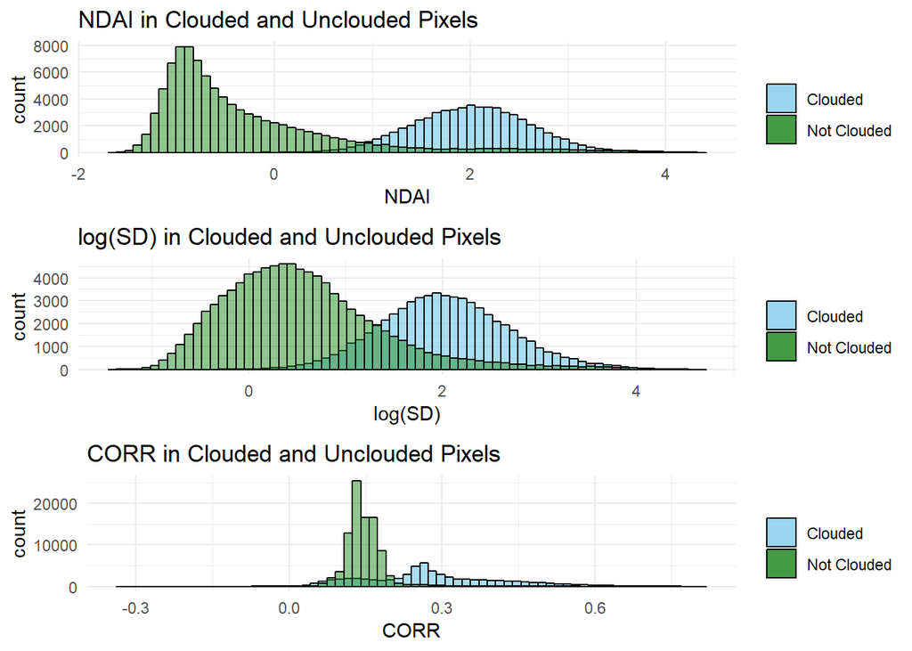

```r
##NDAI
hist_NDAI = ggplot() +
  geom_histogram(data = training_temp[training_temp[,"expert_label"] == 1,], aes(x = NDAI, fill = "Clouded"), bins = 70, color = "black", alpha = 0.7) +
  geom_histogram(data = training_temp[training_temp[,"expert_label"] == -1,], aes(x = NDAI, fill = "Not Clouded"), bins = 70, color = "black", alpha = 0.5) +
  scale_fill_manual("",breaks = c("Clouded", "Not Clouded"), values = c("#87CEEB","#228B22")) + labs(title = "NDAI in Clouded and Unclouded Pixels") +
  theme_minimal()

##SD
hist_logSD = ggplot() +
  geom_histogram(data = training_temp[training_temp[,"expert_label"] == 1,], aes(x = log(SD), fill = "Clouded"), bins = 70, color = "black", alpha = 0.7) +
  geom_histogram(data = training_temp[training_temp[,"expert_label"] == -1,], aes(x = log(SD), fill = "Not Clouded"), bins = 70, color = "black", alpha = 0.5) +
  scale_fill_manual("",breaks = c("Clouded", "Not Clouded"), values = c("#87CEEB","#228B22")) + labs(title = "log(SD) in Clouded and Unclouded Pixels") +
  theme_minimal()

##CORR
hist_CORR = ggplot() +
  geom_histogram(data = training_temp[training_temp[,"expert_label"] == 1,], aes(x = CORR, fill = "Clouded"), bins = 70, color = "black", alpha = 0.7) +
  geom_histogram(data = training_temp[training_temp[,"expert_label"] == -1,], aes(x = CORR, fill = "Not Clouded"), bins = 70, color = "black", alpha = 0.5) +
  scale_fill_manual("",breaks = c("Clouded", "Not Clouded"), values = c("#87CEEB","#228B22")) + labs(title = "CORR in Clouded and Unclouded Pixels") +
  theme_minimal()

##Presenting them together
grid.arrange(hist_NDAI, hist_logSD, hist_CORR, nrow = 3)
```

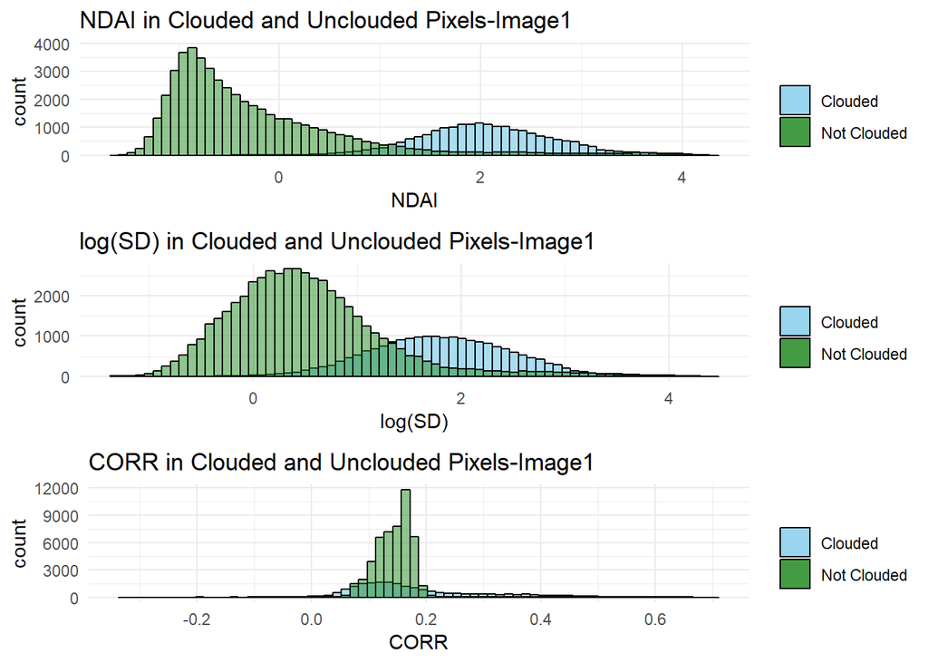

```r
##NDAI
hist_NDAI = ggplot() +
  geom_histogram(data = image1_confident[image1_confident[,"expert_label"] == 1,], aes(x = NDAI, fill = "Clouded"), bins = 70, color = "black", alpha = 0.7) +
  geom_histogram(data = image1_confident[image1_confident[,"expert_label"] == -1,], aes(x = NDAI, fill = "Not Clouded"), bins = 70, color = "black", alpha = 0.5) +
  scale_fill_manual("",breaks = c("Clouded", "Not Clouded"), values = c("#87CEEB","#228B22")) + labs(title = "NDAI in Clouded and Unclouded Pixels-Image1") +
  theme_minimal()

##SD
hist_logSD = ggplot() +
  geom_histogram(data = image1_confident[image1_confident[,"expert_label"] == 1,], aes(x = log(SD), fill = "Clouded"), bins = 70, color = "black", alpha = 0.7) +
  geom_histogram(data = image1_confident[image1_confident[,"expert_label"] == -1,], aes(x = log(SD), fill = "Not Clouded"), bins = 70, color = "black", alpha = 0.5) +
  scale_fill_manual("",breaks = c("Clouded", "Not Clouded"), values = c("#87CEEB","#228B22")) + labs(title = "log(SD) in Clouded and Unclouded Pixels-Image1") +
  theme_minimal()

##CORR
hist_CORR = ggplot() +
  geom_histogram(data = image1_confident[image1_confident[,"expert_label"] == 1,], aes(x = CORR, fill = "Clouded"), bins = 70, color = "black", alpha = 0.7) +
  geom_histogram(data = image1_confident[image1_confident[,"expert_label"] == -1,], aes(x = CORR, fill = "Not Clouded"), bins = 70, color = "black", alpha = 0.5) +
  scale_fill_manual("",breaks = c("Clouded", "Not Clouded"), values = c("#87CEEB","#228B22")) + labs(title = "CORR in Clouded and Unclouded Pixels-Image1") +
  theme_minimal()

##Presenting them together
grid.arrange(hist_NDAI, hist_logSD, hist_CORR, nrow = 3)
```

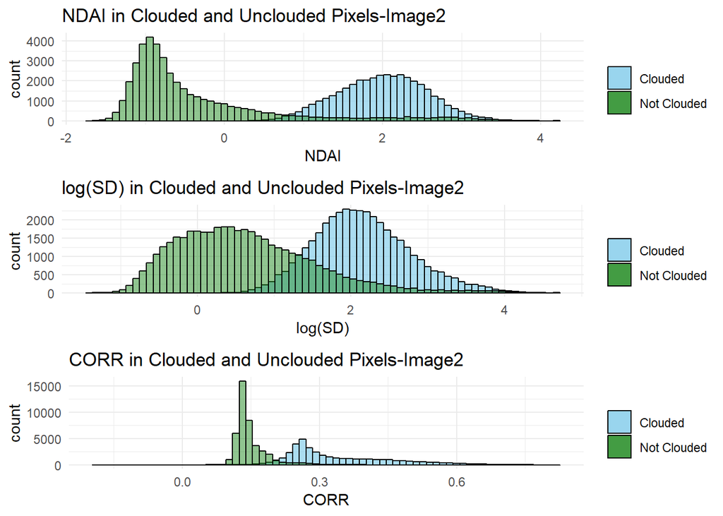

```r
##NDAI
hist_NDAI = ggplot() +
  geom_histogram(data = image2_confident[image2_confident[,"expert_label"] == 1,], aes(x = NDAI, fill = "Clouded"), bins = 70, color = "black", alpha = 0.7) +
  geom_histogram(data = image2_confident[image2_confident[,"expert_label"] == -1,], aes(x = NDAI, fill = "Not Clouded"), bins = 70, color = "black", alpha = 0.5) +
  scale_fill_manual("",breaks = c("Clouded", "Not Clouded"), values = c("#87CEEB","#228B22")) + labs(title = "NDAI in Clouded and Unclouded Pixels-Image2") +
  theme_minimal()

##SD
hist_logSD = ggplot() +
  geom_histogram(data = image2_confident[image2_confident[,"expert_label"] == 1,], aes(x = log(SD), fill = "Clouded"), bins = 70, color = "black", alpha = 0.7) +
  geom_histogram(data = image2_confident[image2_confident[,"expert_label"] == -1,], aes(x = log(SD), fill = "Not Clouded"), bins = 70, color = "black", alpha = 0.5) +
  scale_fill_manual("",breaks = c("Clouded", "Not Clouded"), values = c("#87CEEB","#228B22")) + labs(title = "log(SD) in Clouded and Unclouded Pixels-Image2") +
  theme_minimal()

##CORR
hist_CORR = ggplot() +
  geom_histogram(data = image2_confident[image2_confident[,"expert_label"] == 1,], aes(x = CORR, fill = "Clouded"), bins = 70, color = "black", alpha = 0.7) +
  geom_histogram(data = image2_confident[image2_confident[,"expert_label"] == -1,], aes(x = CORR, fill = "Not Clouded"), bins = 70, color = "black", alpha = 0.5) +
  scale_fill_manual("",breaks = c("Clouded", "Not Clouded"), values = c("#87CEEB","#228B22")) + labs(title = "CORR in Clouded and Unclouded Pixels-Image2") +
  theme_minimal()

##Presenting them together
grid.arrange(hist_NDAI, hist_logSD, hist_CORR, nrow = 3)
```

4. CV function

Please see `report/report.Rmd` or `code/CVgeneric.R` for important limitations on input data types, fold-creation methods, and admissible models. Both copies are identical except that `code/CVgeneric.R` contains some manual testing.

```r
#' @title CVgeneric
#' @description A generic function that takes in a training set(label, features), a loss function,
#' a model, and performs K-fold validation across the training set. Folds are created using random
#' sampling without replacement.
#'
#' train_labels and train_features are assumed to be in tidy format with mathcing number of rows.
#'
#' model should be passable into R's built in predict function to generate prediction.
#'
#' loss function should take in both true labels and estimated labels, and returns an error.
#'
#' Notice we are assuming the labels are named "expert_label".
#'
#' Further Notice we assume the two classes are encoded 0 and 1.
#'
#' @return A list of three: Loss for each fold, Average Loss, and Time consumed for validation.

CVgeneric = function(features, labels, Model, loss, K){
  require(dplyr)
  row.names(features) = 1:nrow(features)
  names(labels) =  1:length(labels)
  raw_sample_size = nrow(features)
  ##Assuming K small and sample-size large, minor trimming should be fine.
  n = raw_sample_size - raw_sample_size %% K
  fold_size = n / K
  shuffled_indices = sample(1:n,n, replace = FALSE)
  fold_belonging = rep(1:K, each = fold_size)
  ##Book keeping
  fold_error = rep(0, K)
  names(fold_error) = paste("Error for fold", seq(1,K))
  ##Time Recording
  time_start = Sys.time()
  for(i in 1:K){
    ##Book keeping.
    val_index = shuffled_indices[fold_belonging == i]
    val_features = features[val_index, ]
    val_labels = labels[val_index]
    train_features = features[-val_index, ]
    train_labels = labels[-val_index]
    train = cbind(train_labels,train_features)
    val = cbind(val_labels, val_features)
    names(train)[1] = "expert_label"
    names(val)[1] = "expert_label"
    ##Intelligently using R's built in method. Wahahahaha.
    updated_model = update(Model, data = train)
    prediction = predict(updated_model, newdata = val, type = "response")
    ##Data type stuff. This part for R's built in Logistics Regression prediction.
    if(!is.list(prediction)){
      names(prediction) = NULL
      predicted_labels = prediction
      predicted_labels[prediction > 0.5] = 1
      predicted_labels[prediction <= 0.5] = 0
      }
    ##This part for RDA model in package klaR.
    else{
      predicted_labels = prediction$class
      }
    fold_error[i] = loss(predicted_labels, val_labels)
    }
  time_end = Sys.time()
  average_error_across_fold = mean(fold_error)
  result = list(FoldLoss = fold_error, AveLoss = average_error_across_fold,
                TimeElapsed = (time_end - time_start))
  return(result)
}


CVgeneric_cloud = function(train, Model, loss, K){
  labels = train[,"expert_label"]
  features = train[, which(names(train) != "expert_label")]
  return(CVgeneric(features, labels, Model, loss, K))
}

CVSet_nonrandom = function(Model){
  updated_model = update(Model, data = train_nonrandom)
  val_labels = val_nonrandom[,"expert_label"]
  prediction = predict(updated_model, newdata = val_nonrandom, type = "response")
  if(!is.list(prediction)){
      names(prediction) = NULL
      predicted_labels = prediction
      predicted_labels[prediction > 0.5] = 1
      predicted_labels[prediction <= 0.5] = 0
      }
    ##This part for RDA model in package klaR.
    else{
      predicted_labels = prediction$class
    }
  CVset_error = classification_error(predicted_labels, val_labels)
  return(CVset_error)
}


CVSet_random = function(Model){
  updated_model = update(Model, data = train_random)
  val_labels = val_random[,"expert_label"]
  prediction = predict(updated_model, newdata = val_random, type = "response")
  if(!is.list(prediction)){
      names(prediction) = NULL
      predicted_labels = prediction
      predicted_labels[prediction > 0.5] = 1
      predicted_labels[prediction <= 0.5] = 0
      }
    ##This part for RDA model in package klaR.
    else{
      predicted_labels = prediction$class
    }
  CVset_error = classification_error(predicted_labels, val_labels)
  return(CVset_error)
}


classification_error = function(true, predicted){
  return(mean(true != predicted))
}

image3_confident[,which(names(image3_confident) != "expert_label")] %>% dim()
```

```
## [1] 54996    10
```

### 3. Model fitting

1. Model fitting

For each scheme, we will choose a basket of hyperparameter values, fit the model for each combination of hyperparamters, check if the assumptions are statisfied, and use cross validation (both K-fold and validation set) to pick the potentially optimal choice of hyperparameters.

We won’t touch the test set in this part. This is to ensure the model selection is completely based on using available data, which best mimics a real-life prediction situation.

1. Penalized Logistics Regression
2. Regularized Discriminant Analysis

Rationale:

LDA model assumes each sample’s features are generated through a multivariate mixed-Gaussian, and that their class-conditioned distributions share the same covariance but differ in mean. Geometrically, this means that for each class, any generated data cloud (in feature space, with suffciently large sample size) would be the shape of an ellipsoid, and that such ellipsoids for different classes only differ in mean but not in shape. QDA, on the other hand, allows each class’s ellipsoid to have completely different shapes.

RDA falls in between the spectrum. It models each class’s variance using a weighted average of global covaraince and class-specific covariance: $\Sigma_{k}^{RDA} = \alpha\Sigma + (1-\alpha)\Sigma_k$, and thus allows class-specfic ellipsoids to possess flexible degree of homogeninality in shape. Hyperparamter $\alpha$ represents the strength of shape-homogeniality.

Feature selection: We only use `CORR`, `NDAI` and `log(SD)`(log to disperse the distribution of SD) for RDA fitting. Testing Gaussian-ness in high dimension is hard, but if we keep the dimension of feature to three, we might use some visualization technique to justfiy the Gaussian-ness.

Testing of Assumptions: Rigorously speaking, we have to test for each class both the Gausian-ness and the iid-ness of features. We did a quick 3D sketch of feature space for clouded pixels (for the randomly splitted validation set), where ellipsoidal dispersion looks reasonable; we also sketched its projections onto pair-wise feature space (graph not included to save space), and the elliptic shapes once again show up. The same pattern is observed among unclouded pixels. We have reasons to believe the Gaussian-need of conditional distribution of features.

The iid assumption is harder to test. For discriminative methods we can look at residuals. How do we do that for generative methods? We don’t know.

Professor Yu mentioned in class that even models that don’t satisfy their own assumptions can prove to be useful predictive scheme. So the assumption testing isn’t of paramount importance here. We focus on other model selection metrics.

Cross validation: We do two types of cross validation. First one is K-fold, the other one is single validation set. For K-fold, we report the average loss across folds, and also the time consumption. For the validation set approach, we report the errors on two different validation sets, one sampled randomly and the other one not. As we explained in Q2 part a, we expect the non-random set to identify the method’s strength over potentially unbalanced data, and the random set for general data.

We keep these two candidates in mind.

```r
##Model fitting
rda_0 = rda(expert_label ~ CORR + NDAI + log(SD), data = train_nonrandom, gamma = 0, lambda = 0, crossval = FALSE)
rda_0.25 = rda(expert_label ~ CORR + NDAI + log(SD), data = train_nonrandom, gamma = 0, lambda = 0.25, crossval = FALSE)
rda_0.5 = rda(expert_label ~ CORR + NDAI + log(SD), data = train_nonrandom, gamma = 0, lambda = 0.5, crossval = FALSE)
rda_0.75 = rda(expert_label ~ CORR + NDAI + log(SD), data = train_nonrandom, gamma = 0, lambda = 0.75, crossval = FALSE)
rda_1 = rda(expert_label ~ CORR + NDAI + log(SD), data = train_nonrandom, gamma = 0, lambda = 1, crossval = FALSE)


##5-fold CV
CVresult_rda0 = CVgeneric_cloud(training_temp, rda_0,loss = classification_error, K = 5)
CVresult_rda0.25 = CVgeneric_cloud(training_temp, rda_0.25,loss = classification_error, K = 5)
CVresult_rda0.5 = CVgeneric_cloud(training_temp, rda_0.5,loss = classification_error, K = 5)
CVresult_rda0.75 = CVgeneric_cloud(training_temp, rda_0.75,loss = classification_error, K = 5)
CVresult_rda1 = CVgeneric_cloud(training_temp, rda_1,loss = classification_error, K = 5)

rda_CV5fold_result = matrix(0,nrow = 5, ncol = 2)
rownames(rda_CV5fold_result) = paste0("RDA(alpha = ", c(0,0.25,0.5,0.75,1), ")")
colnames(rda_CV5fold_result) = c("RDA Average Error", "RDA Time Elasped for five-fold CV(sec)")
rda_CV5fold_result[1, ] = c(CVresult_rda0$AveLoss, CVresult_rda0$TimeElapsed)
rda_CV5fold_result[2, ] = c(CVresult_rda0.25$AveLoss, CVresult_rda0.25$TimeElapsed)
rda_CV5fold_result[3, ] = c(CVresult_rda0.5$AveLoss, CVresult_rda0.5$TimeElapsed)
rda_CV5fold_result[4, ] = c(CVresult_rda0.75$AveLoss, CVresult_rda0.75$TimeElapsed)
rda_CV5fold_result[5, ] = c(CVresult_rda1$AveLoss, CVresult_rda1$TimeElapsed)



##Validation Set

rda_CVset_Result = matrix(0,nrow = 5, ncol = 2)
rownames(rda_CVset_Result) = paste0("RDA(alpha = ", c(0,0.25,0.5,0.75,1), ")")
colnames(rda_CVset_Result) = c("RDA Error Non-random", "RDA Error Random")


##Non-random
rda_CVset_Result[1,1] = CVSet_nonrandom(rda_0)
rda_CVset_Result[2,1] = CVSet_nonrandom(rda_0.25)
rda_CVset_Result[3,1] = CVSet_nonrandom(rda_0.5)
rda_CVset_Result[4,1] = CVSet_nonrandom(rda_0.75)
rda_CVset_Result[5,1] = CVSet_nonrandom(rda_1)

##Random
rda_CVset_Result[1,2] = CVSet_random(rda_0)
rda_CVset_Result[2,2] = CVSet_random(rda_0.25)
rda_CVset_Result[3,2] = CVSet_random(rda_0.5)
rda_CVset_Result[4,2] = CVSet_random(rda_0.75)
rda_CVset_Result[5,2] = CVSet_random(rda_1)

rda_CV5fold_result
```

```
##                   RDA Average Error RDA Time Elasped for five-fold CV(sec)
## RDA(alpha = 0)           0.06060171                               47.76108
## RDA(alpha = 0.25)        0.06471107                               43.90154
## RDA(alpha = 0.5)         0.06516186                               38.57982
## RDA(alpha = 0.75)        0.06543625                               38.81619
## RDA(alpha = 1)           0.06695848                               38.97473
```

```r
rda_CVset_Result
```

```
##                   RDA Error Non-random RDA Error Random
## RDA(alpha = 0)             0.002833638       0.06135995
## RDA(alpha = 0.25)          0.002787934       0.06517535
## RDA(alpha = 0.5)           0.002833638       0.06548895
## RDA(alpha = 0.75)          0.002970750       0.06575027
## RDA(alpha = 1)             0.002970750       0.06757957
```

```r
##Visualizing
prediction_rda0 = predict(rda_0, newdata = val_random, type = "response")
prediction_rda0$class
```

[output not shown]

[output cut: 856 more lines]

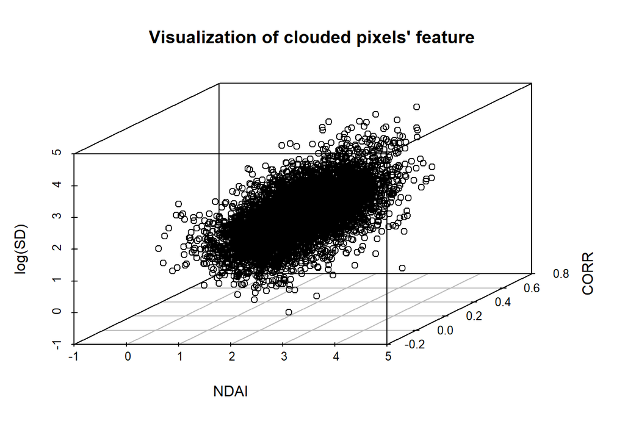

```r
scatterplot3d(x = val_random[val_random$expert_label == 1,"NDAI"], y = val_random[val_random$expert_label == 1,"CORR"], z = log(val_random[val_random$expert_label == 1,"SD"]), xlab = "NDAI", ylab = "CORR", zlab = "log(SD)", main = "Visualization of clouded pixels' feature")
```

3. LDA with feature selection

Does it make sense to only consider the three custom-created features? Would inclusion of geological information(`x` and `y`) help improve the model quality? What about the raw radiation readings?

In this subsection, we attempt to address these natural concerns by cross validating over four models: LDA that only includes custom features, one that has custom+geological features, another one with custom+radiation_reading, and the full model.

```r
##Model fitting
lda_m1 = rda(expert_label ~ CORR + NDAI + log(SD), data = train_nonrandom, gamma = 0, lambda = 0, crossval = FALSE)
lda_m2 = rda(expert_label ~ CORR + NDAI + log(SD) + x + y, data = train_nonrandom, gamma = 0, lambda = 0, crossval = FALSE)
lda_m3 = rda(expert_label ~ .- x - y, data = train_nonrandom, gamma = 0, lambda = 0, crossval = FALSE)
lda_m4 = rda(expert_label ~ ., data = train_nonrandom, gamma = 0, lambda = 0, crossval = FALSE)

##CV
##Kfold
lda_CV5fold_result = matrix(0,nrow = 4, ncol = 2)
rownames(lda_CV5fold_result) = c("custom", "custom+geo", "custom+reading", "full")
colnames(lda_CV5fold_result) = c("LDA Average Error", "LDA Time Elasped for five-fold CV(sec)")
CVresult_ldam1 = CVgeneric_cloud(training_temp, lda_m1, classification_error, 5)
CVresult_ldam2 = CVgeneric_cloud(training_temp, lda_m2, classification_error, 5)
CVresult_ldam3 = CVgeneric_cloud(training_temp, lda_m3, classification_error, 5)
CVresult_ldam4 = CVgeneric_cloud(training_temp, lda_m4, classification_error, 5)

lda_CV5fold_result[1, ] = c(CVresult_ldam1$AveLoss, CVresult_ldam1$TimeElapsed)
lda_CV5fold_result[2, ] = c(CVresult_ldam2$AveLoss, CVresult_rda0.25$TimeElapsed)
lda_CV5fold_result[3, ] = c(CVresult_ldam3$AveLoss, CVresult_rda0.5$TimeElapsed)
lda_CV5fold_result[4, ] = c(CVresult_ldam4$AveLoss, CVresult_rda0.75$TimeElapsed)


##Validation Set
##NonRandom
lda_CVset_Result = matrix(0,nrow = 4, ncol = 2)
rownames(lda_CVset_Result) = c("custom", "custom+geo", "custom+reading", "full")
colnames(lda_CVset_Result) = c("Error Non-Random Validation", "Error Random Validation")

lda_CVset_Result[1,1] = CVSet_nonrandom(lda_m1)
lda_CVset_Result[2,1] = CVSet_nonrandom(lda_m2)
lda_CVset_Result[3,1] = CVSet_nonrandom(lda_m3)
lda_CVset_Result[4,1] = CVSet_nonrandom(lda_m4)


##Random
lda_CVset_Result[1,2] = CVSet_random(lda_m1)
lda_CVset_Result[2,2] = CVSet_random(lda_m2)
lda_CVset_Result[3,2] = CVSet_random(lda_m3)
lda_CVset_Result[4,2] = CVSet_random(lda_m4)

lda_CV5fold_result
```

```
##                LDA Average Error LDA Time Elasped for five-fold CV(sec)
## custom                0.06058864                               41.72238
## custom+geo            0.05368308                               43.90154
## custom+reading        0.06478947                               38.57982
## full                  0.05118087                               38.81619
```

```r
lda_CVset_Result
```

```
##                Error Non-Random Validation Error Random Validation
## custom                         0.002833638              0.06135995
## custom+geo                     0.003153565              0.05435635
## custom+reading                 0.006992687              0.06585481
## full                           0.005712980              0.05127267
```

iv.Random Forest

2. ROC curve

ROC curve tells us about a model’s false positive and false negative rate. In part a) we picked the models with the best overall error rate (over different validation sets). In this part b) we will use the false positive and false negative rate as a thresholding mechnism – as long as a candidate model doesn’t perform too poorly in terms of type I or type II error, we will regard the model as admissible.

We use the randomly-sampled validation set to calculate the false postive and negative rate for each method. We arbitrarily set both thresholds at 10% = 0.1, meaning if either false positive or false negative rate is higher than 0.1, we discard the model.

The table below shows false positive and negative rate. The logistics model has a false positive rate of 0.18, which is higher than our 0.1 bar. We won’t use logistics model for prediction purpose.

```r
##Two RDA methods
true_boolean = (val_random$expert_label == 1)
false_boolean = (val_random$expert_label != 1)
pred_rda0_random_val = predict(rda_0, newdata = val_random, type = "response")
pred_labels_rda0_random_val = pred_rda0_random_val$class
rda0_false_positive = sum(pred_labels_rda0_random_val[false_boolean] == 1)/sum(false_boolean)
rda0_false_nagetive = sum(pred_labels_rda0_random_val[true_boolean] != 1)/sum(true_boolean)

pred_rda0.25_random_val = predict(rda_0.25, newdata = val_random, type = "response")
pred_labels_rda0.25_random_val = pred_rda0.25_random_val$class
rda0.25_false_positive = sum(pred_labels_rda0.25_random_val[false_boolean] == 1)/sum(false_boolean)
rda0.25_false_nagetive = sum(pred_labels_rda0.25_random_val[true_boolean] != 1)/sum(true_boolean)

##One LDA feature methods
pred_lda_m2_random_val = predict(lda_m2, newdata = val_random, type = "response")
pred_labels_lda_m2_random_val = pred_lda_m2_random_val$class
lda_m2_false_positive = sum(pred_labels_lda_m2_random_val[false_boolean] == 1)/sum(false_boolean)
lda_m2_false_nagetive = sum(pred_labels_lda_m2_random_val[true_boolean] != 1)/sum(true_boolean)


ROC_result = matrix(c(rda0_false_positive,
rda0_false_nagetive,
rda0.25_false_positive,
rda0.25_false_nagetive,
lda_m2_false_positive,
lda_m2_false_nagetive,
0.18634108122225124,
0.07971270458024256,
0.013874066168623266,
0.037717335845205854), nrow = 5, ncol = 2, byrow = TRUE)
rownames(ROC_result) = c("RDA_0", "RDA_0.25", "LDA custom+geo", "Logistics", "RandomForest")
colnames(ROC_result) =  c("False Positive Rate", "False Negative Rate")

ROC_result
```

```
##                False Positive Rate False Negative Rate
## RDA_0                   0.06786478          0.06095596
## RDA_0.25                0.06897732          0.06538668
## LDA custom+geo          0.05400086          0.05061762
## Logistics               0.18634108          0.07971270
## RandomForest            0.01387407          0.03771734
```

### 4. In-depth Diagnotics

We did the diagnostics in Part3 using validation set only. In Part4 we reintroduce the test set to see how models perform in real-life setting.

1. Further diagnostics on candidate models

In this subsection, we use three metrics: test-time performance, intepretability of features, and stablitiy under perturbed training data.

Test-time Accuracy:

All three RDA models perform way worse on test sets than in validation set, each having error rate over 21%. Even though we arrived at the three linear discriminant models from different thought process(one from feature selection, two from regularization tuning), they are similiar in nature, and in test-time performance. For simplicity’s sake we will just use the LDA model with custom+geo features.

Intepretability & Feature Importance:

Stability under perturbed training data:

```r
test_pred_rda_0 = predict(rda_0, newdata = test, type = "response")
testError_rda_0 = mean(test_pred_rda_0$class != test$expert_label)
test_pred_rda_0.25 = predict(rda_0.25, newdata = test, type = "response")
testError_rda_0.25 = mean(test_pred_rda_0.25$class != test$expert_label)
test_pred_lda_m2 = predict(lda_m2, newdata = test, type = "response")
testError_lda_m2 = mean(test_pred_lda_m2$class != test$expert_label)

testError_rda_0
```

```
## [1] 0.2200706
```

```r
testError_rda_0.25
```

```
## [1] 0.2119972
```

```r
testError_lda_m2
```

```
## [1] 0.2524002
```

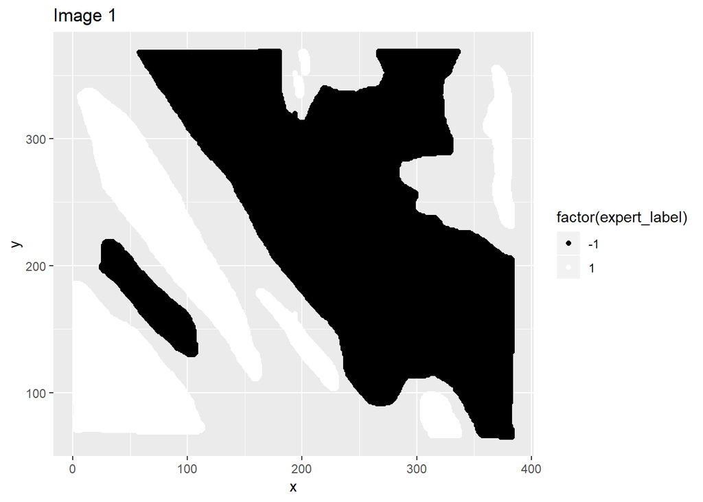

```r
image1_size = nrow(image1_confident)
perturbed_index = sample(1:image1_size, 0.01*image1_size)
perturbed_image1 =  image1_confident
perturbed_image1$expert_label[perturbed_index] = -perturbed_image1$expert_label[perturbed_index]


ggplot(image1_confident) + geom_point(aes(x = x, y = y, color = factor(expert_label))) + scale_color_manual(values = c("black","white")) +
  labs(title = "Image 1")
```

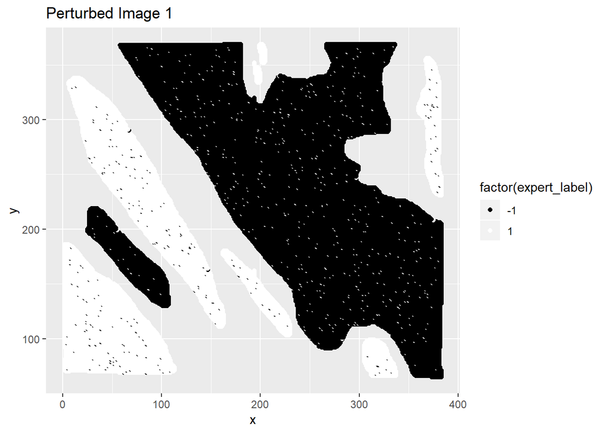

```r
ggplot(perturbed_image1) + geom_point(aes(x = x, y = y, color = factor(expert_label))) + scale_color_manual(values = c("black","white")) +
  labs(title = "Perturbed Image 1")
```

```r
trainig_temp_perturbed = rbind(perturbed_image1, image2_confident)
perturbed_lda_m2 = update(lda_m2, data = training_temp)
perturbed_lda_m2_prediction = predict(perturbed_lda_m2, newdata = test, type = "response")
perturbed_error = mean(perturbed_lda_m2_prediction$class != test$expert_label)
perturbed_error
```

```
## [1] 0.2477998
```

2. Graphical distribution of misclassifications

A comparison between predicted image and the actual test image is shown below. For the LDA model, the error concentrates in two parts: one small patch near the left boundery is falsely positive, and a big patch in the fourth quadrant is false negative.

We think that the culprit for such concentrated errors is imbalance in training data. Looking back at image1 and image2, we realize in both images the left patch is mostly white, and the bottm right corners are mostly black. Such problem might be addressed through including more images in the training dataset.

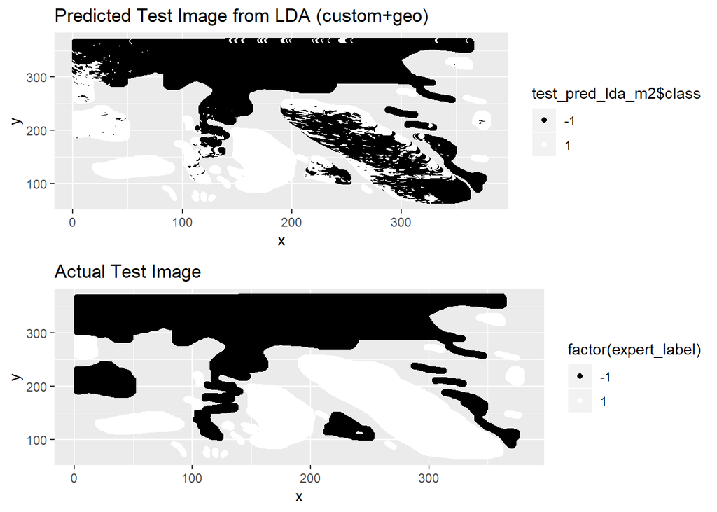

```r
predicted_test_image_plot = ggplot(test) + geom_point(aes(x = x, y = y, color = test_pred_lda_m2$class)) + scale_color_manual(values = c("black","white")) +
  labs(title = "Predicted Test Image from LDA (custom+geo)")
actual_test_image_plot = ggplot(test) + geom_point(aes(x = x, y = y, color = factor(expert_label))) + scale_color_manual(values = c("black","white")) + labs(title = "Actual Test Image")
grid.arrange(predicted_test_image_plot, actual_test_image_plot)
```

3. Can we improve?
4. Does data splitting matter?

Not by much, as long as we’re using image3 as the test set. It makes sense because neither logistics nor RDA models in our implementation contains interaction terms, and thus ignore any space-based structures.

5. Conclusion